# Report on Prison Admission Trends in the U.S.

Simon Cao

2/25/2022

## Introduction

The data set used as the basis of the analysis in this report is from [this repository](https://github.com/vera-institute/incarceration-trends/blob/master/incarceration_trends.csv). This data set from the Vera Institute of Justice provides county-level data on the topic of incarceration in the U.S. with 153,811 observations and 121 variables.

The United States has a significant social problem in racial justice, especially in racial discrimination by law enforcement. In this analysis, we focus on the U.S. prison admission rate of people of color to identify the racial discrimination involved.

# Summary Information

In general, people of color suffer significant larger prison admission rate than average with the black population stands out. For example, In 2016, the average prison admission rate is 354.1565, but for the black population, the number is significantly higher, with an average of 1,105.782, and a maximum of 17,725.75, comparing to the white population average 334.5536. However, through out the years, this condition seems to be improving. From 2011 to 2016, the average prison admission rate for black people decreased by -156.6715. All detailed numbers are listed below.

| year | avg_prison_admission_rate | avg_white_prison_admission_rate | avg_black_prison_admission_rate | avg_latinx_prison_admission_rate | avg_appi_prison_admission_rate | avg_native_prison_admission_rate |
| --- | --- | --- | --- | --- | --- | --- |
| 2011 | 361.5695 | 307.3881 | 1262.454 | 268.8296 | 9.357368 | 457.3945 |
| 2012 | 346.8422 | 301.2379 | 1087.794 | 235.0930 | 11.371037 | 384.5441 |
| 2013 | 364.2568 | 315.5961 | 1127.171 | 209.9194 | 9.817673 | 407.2460 |
| 2014 | 360.9086 | 318.3466 | 1036.924 | 223.8887 | 12.097241 | 459.3734 |
| 2015 | 352.4591 | 315.0292 | 1054.349 | 229.0874 | 14.731585 | 421.0585 |
| 2016 | 354.1565 | 334.5536 | 1105.782 | 246.6713 | 19.163079 | 530.3730 |

- The prison admission rate is established on a per 100,000 people basis.

## Trends over time plot

The following time trend plot gives a sense of the difference in prison admission between race groups changes of the situation over time. From the graph, we could see that the black population has significantly higher prison admission rate than other race groups. However, it seems like the situation is improving over the years.

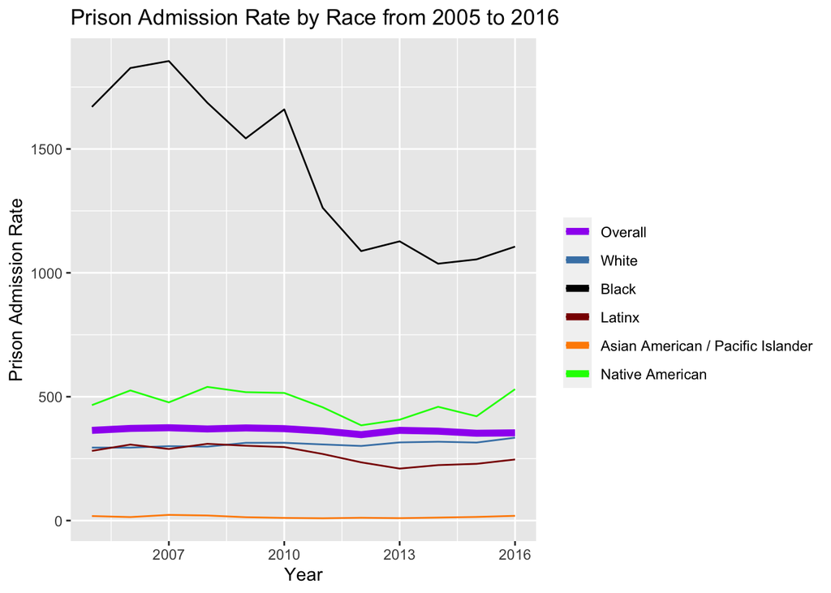

## Variable Comparison Plot

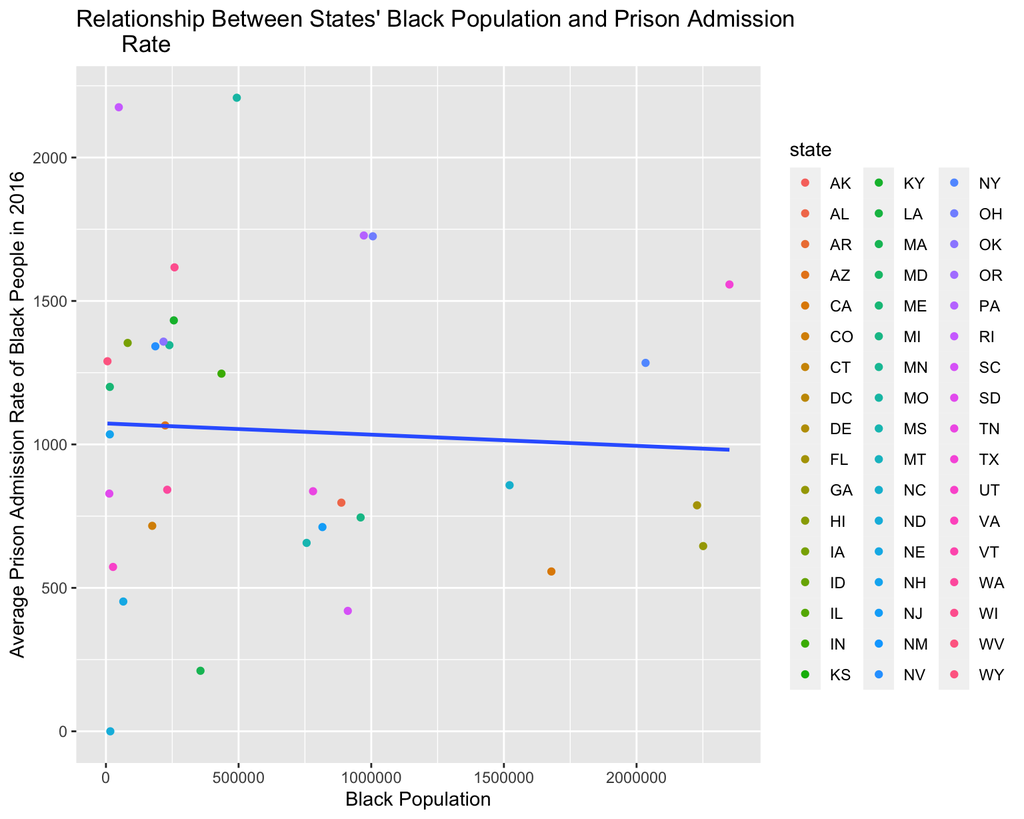

## Map plot

The following is a heat map of prison admission rate of black people in 2016. The map reveals geological distribution of discrimination, high lighting more severe racial injustice in central America with Missouri having the highest prison admission rate for black people.

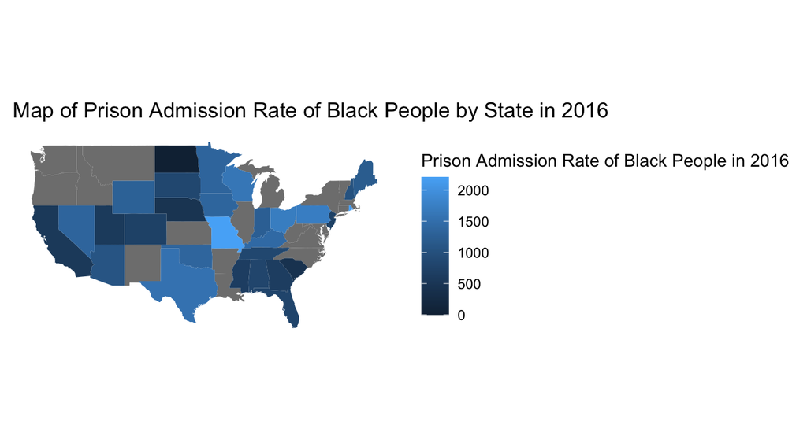